# R Notebook

# You have been provided some customer data from a shopping centre. Do some exploratory analysis on the data. Comment on findings.

```r
customers <- read_csv("data/mall_customers.csv") %>%
  clean_names()

head(customers)
skimr::skim(customers)

customers %>%
  ggpairs()

customers %>%
  ggplot() +
  aes(age) +
  geom_point(aes(y = spending_score_1_100), colour = "blue")

# very clear drop in spending score around 40

customers %>%
  ggplot() +
  aes(gender) +
  geom_jitter(aes(y = annual_income_k), colour = "dark green")

customers %>%
  ggplot() +
  aes(gender) +
  geom_jitter(aes(y = spending_score_1_100), colour = "dark green")
#

scaled_customers <- customers %>%
  column_to_rownames("customer_id") %>%
  mutate(across(where(is.numeric), scale)) %>%
  select(-gender, -age)
```

[output not shown]

# We are interested in creating a marketing campaign to target customers based on their spending score and annual income. Perform a k-means clustering to find if there are meaningful clusters in the data to target the customers.

# Perform k-means clustering and chose a value of k.

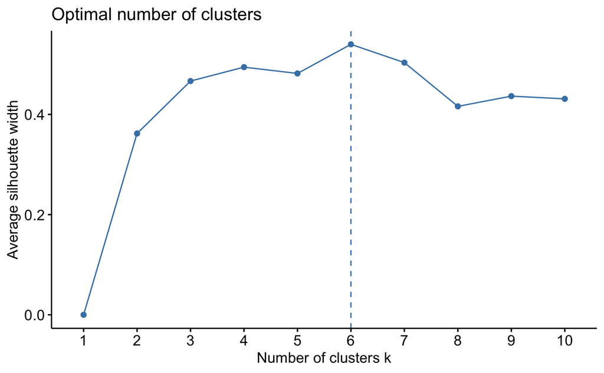

# Visualise the clustering for your chosen value of k.

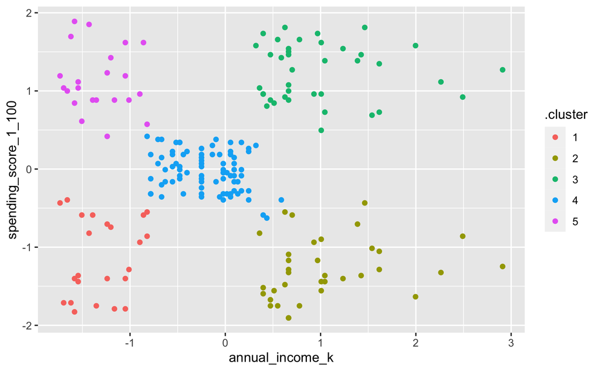

```r
customer_clusterings %>%
  unnest(cols = augmented) %>%
  filter(k == 5) %>%
  ggplot() +
  aes(annual_income_k, spending_score_1_100, colour = .cluster) +
  geom_point()
```

# Do you think the clustering seems a good fit for this data?

I would say the clustering is an excellent fit for this data

# Comment on the attributes on one or two of the clusters (maybe even give them a label if you like - like in section 4.1 of the ‘Segmentation & clustering intro’ lesson).

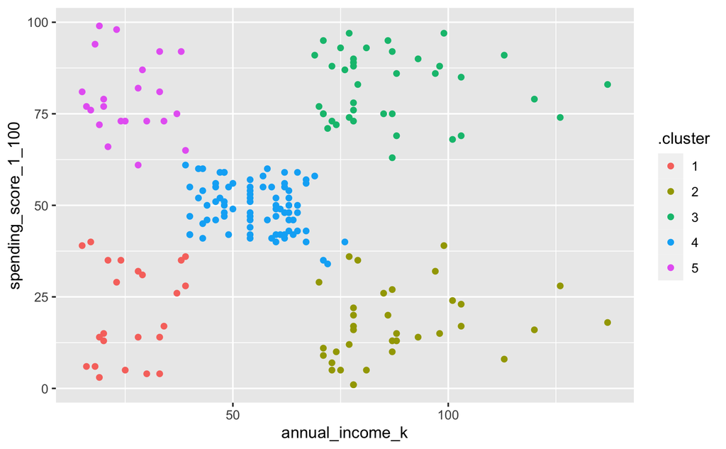

```r
cluster_lab <- customer_clusterings %>%
  filter(k == 5) %>%
  unnest(cols = augmented) %>%
  select(.cluster)

customer_w_clusters <- customers %>%
  bind_cols(cluster_lab)

customer_w_clusters %>%
  ggplot() +
  aes(x = annual_income_k, y = spending_score_1_100, colour = .cluster) +
  geom_point()
```

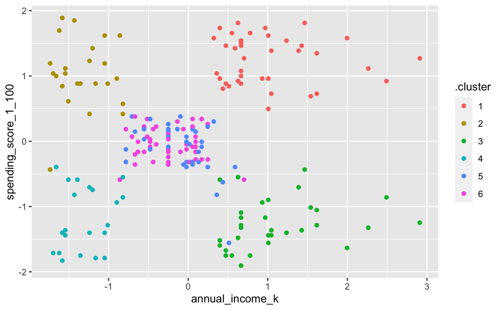

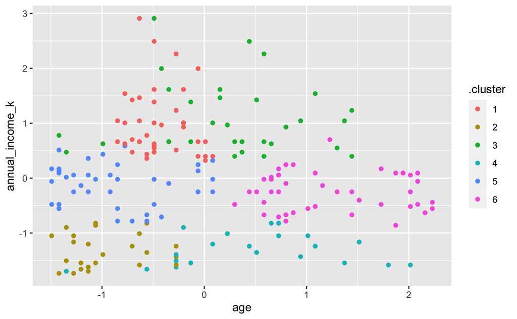

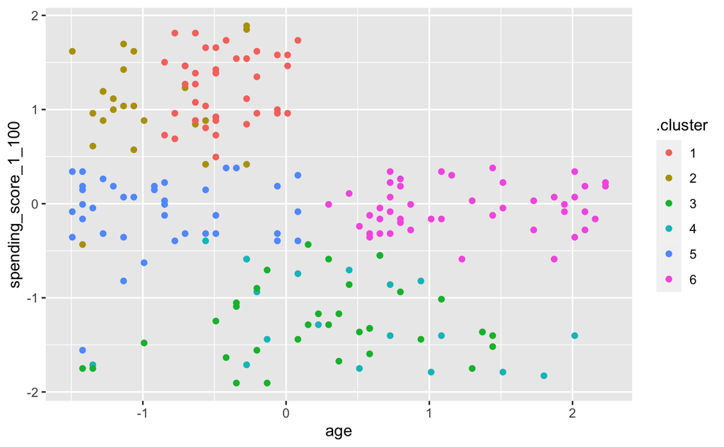

```r
inc_sco
age_inc

age_sco
```